# Learning Regression 02 - Multilevel

Nate Breznau

7/25/2021

```r
load(here::here("data","socstat.Rda"))
```

### Two-Levels = Two-Results

In two-level multilevel modeling there are really two models happening at once. There are N-models for the N number of levels in multilevel modeling. We will just focus on two for now in the ISSP data, countries and individuals.

Suggested reading:

Snijders, T. A. B., and R. J. Bosker. 1994. “Modeled Variance in Two-Level Models.” *Sociological Methods & Research* 22(3):342–63. doi: 10.1177/0049124194022003004.

The Snijders and Bosker reading’s main purpose is to propose how to measure explained variance in a multilevel model, but we can learn the basics of multlevel modeling by working through it.

The article starts with *“The concept of explained variance is well-known in multiple regression analysis: it gives an answer to the question, how much of the variability of the dependent variable is accounted for by the linear regression on the explanatory variables.”

Remember also that a standardized regression coefficient is roughly identical to a correlation in a regression with just one independent variable. Therefore we use the following simple equation where we predict support for ‘it is the governments responsibility to reduce income differences between those with high and low incomes’ (we label this variable *incdiff*) by support for ‘there is too much inequality between rich and poor in [this country]’ (label is *inclarge*)

$Y_{i} = B_{0} + B_{1}X_{i} + E_{i}$

Where: $Y$ = *incdiff*

$X$ = *inclarge*

$i$ = individual survey respondents

And now the regression visualized

```r
m01 <- lm(incdiff ~ inclarge, data = df) # the regression from the equation above
summary(m01)
```

```
##
## Call:
## lm(formula = incdiff ~ inclarge, data = df)
##
## Residuals:
##     Min      1Q  Median      3Q     Max
## -3.2091 -0.6886 -0.3187  0.4210  3.3114
##
## Coefficients:
##             Estimate Std. Error t value Pr(>|t|)
## (Intercept) 1.058426   0.005988   176.7   <2e-16 ***
## inclarge    0.630137   0.002824   223.2   <2e-16 ***
## ---
## Signif. codes:  0 '***' 0.001 '**' 0.01 '*' 0.05 '.' 0.1 ' ' 1
##
## Residual standard error: 0.9702 on 124926 degrees of freedom
##   (118335 observations deleted due to missingness)
## Multiple R-squared:  0.285,  Adjusted R-squared:  0.285
## F-statistic: 4.98e+04 on 1 and 124926 DF,  p-value: < 2.2e-16
```

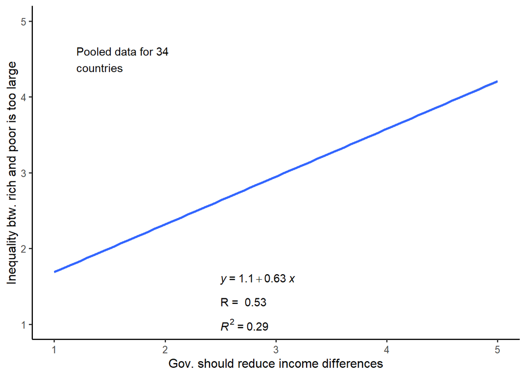

```r
#create plot with regression line and regression equation and r^2
mmmPOOLED <- ggplot(data=df, aes(x=inclarge, y=incdiff)) +
        geom_smooth(method="lm") +
        #geom_point() +
        xlim(1,5) + # make both axes the same for easier visualization
        ylim(1,5) +
        stat_regline_equation(label.x=2.5, label.y=1.6, hjust = 0) +
        stat_cor(aes(label=..rr.label..), label.x=2.5, label.y=1, hjust = 0) +
        labs(x = "Gov. should reduce income differences", y = "Inequality btw. rich and poor is too large") +
        annotate(geom = "text", x = 2.5, y = 1.3, label = paste("R = ", round(cor(df$incdiff, df$inclarge, use = "pairwise.complete.obs"),2)),
                      hjust = 0,
                      ) +
        annotate(geom = "text", x = 1.2, y = 4.5,
                 label = paste0("Pooled data for ",length(unique(df$iso3c[!is.na(df$inclarge)])),"\ncountries"),
                 hjust = 0) + #add number of countries to plot
        theme_classic2() +
        theme(
          axis.title = element_text(size = 8)
        )

mmmPOOLED +
  theme(
    axis.title = element_text(size = 12)
  )
```

As we are aware, this regression line (i.e., correlation) is different in different countries. For example the correlation was lower in the US than in Sweden. That means that the $R^2$ is also different because it is really just the correlation (i.e., the regression coefficient $B_{1}$) squared.

But to be clear, $R^2$ is the most common statistic used to identify what Snijders and Bosker refer to as “explained variance” in the first sentence of their article.

Lets look at the association in all 34 countries now.

```r
# get all intercepts and slopes
fitted_models = df %>% # have to use equal sign here because it is a function
  subset(!is.na(incdiff) & !is.na(inclarge)) %>% # remove missing cases
  group_by(iso3c) %>% # group by country
  do(model = lm(incdiff ~ inclarge, data = .)) #run regression for each country

# plot all at once

# make a data frame of all wanted x values
x <- 1:5
dfx <- as.data.frame(x)

# now loop to create a plot for each intercept and coefficient from each country's regression

for (j in 1:length(unique(fitted_models$iso3c))){
  dfx <- df %>% # subset data to only that country and remove missing
    subset(iso3c == fitted_models$iso3c[j]) %>%
    subset(!is.na(incdiff) & !is.na(inclarge))

  plot1 <- ggplot(data = dfx, aes(x = inclarge, y = incdiff, group = wave, color=as.factor(wave))) +
           geom_smooth(method = 'lm', se=T) +
           xlim(1,5) +
           ylim(1,5) +
           annotate(geom = "text", x = 2.5, y = 1.6, label = paste0("y = ",
                                                              round(fitted_models$model[[j]]$coefficients[1],1),
                                                              " + ",
                                                              round(fitted_models$model[[j]]$coefficients[2],2),"x"), hjust = 0,) +
           annotate(geom = "text", x = 2.5, y = 1, label = paste("R^2 = ", round(cor(dfx$incdiff, dfx$inclarge)^2,2)),
                      hjust = 0,
                      ) +
           stat_cor(label.x = 2.5, label.y = 1.3, hjust = 0, p.accuracy = 0.001) +
           labs(title = paste0(fitted_models$iso3c[j]), color='Wave') +
           theme_classic2() +
        theme(axis.title = element_blank())
             #theme(axis.title = element_blank(), legend.key.size = unit(2, 'mm'), legend.direction = "horizontal",legend.position="top", legend.justification="right", legend.margin=margin(0,0,0,0))


assign(paste0("mmm",fitted_models$iso3c[j]), plot1)

}
```

```r
# now gather all and plot with ggarrange

agg_png(filename = here::here("learning","images","multiplot.png"), res = 72, width = 1200, height = 1200)
ggarrange(mmmPOOLED, mmmAUS, mmmAUT, mmmBGR, mmmCAN, mmmCHE, mmmCHL,
mmmCYP, mmmCZE, mmmDEU, mmmDNK, mmmESP, mmmFIN, mmmFRA,
mmmGBR, mmmHRV, mmmHUN, mmmIRL, mmmISR, mmmITA, mmmJPN,
mmmLVA, mmmNLD, mmmNOR, mmmNZL, mmmPHL, mmmPOL, mmmPRT,
mmmRUS, mmmSVK, mmmSVN, mmmSWE, mmmTHA, mmmUSA, mmmZAF, common.legend = TRUE)
dev.off()
```

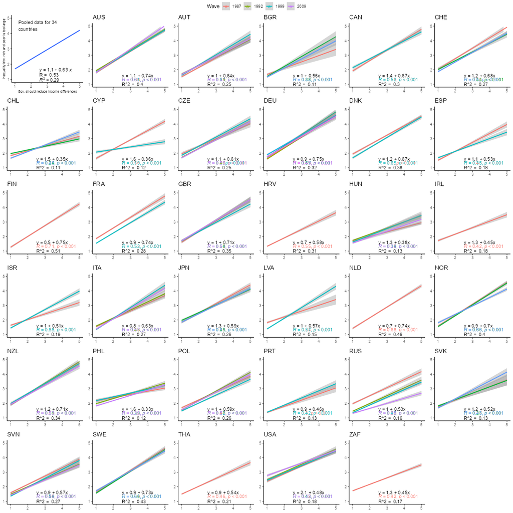

```r
knitr::include_graphics(here::here("learning","images","multiplot.png"))
```

Snijders and Bosker offer Equation 2 as the maximum likelihood estimator that is used to find the regression lines in a multilevel model. A multilevel model is called a “general linear model” instead of “ordinary least squares” because it is not possible to minimize the sum of the squared residual, because there is not one residual! As you can see from the figure above, when we try to estimate a regression that can fit the lines in all these countries at once plus the pooled sample of all countries together this leads to not one set of residuals but there are 35 ‘residuals’, one for each country and 1 overall residual for all the countries pooled together. So this maximum likelihood is trying to minimize the log-likelihood which is a combination of $SS_{w}$ and $SS_{b}$ (don’t worry about how this maximum-likelihood equation works for now, that is for another lesson). But what the heck are the $SS_{w}$ and $SS_{b}$? These are the **within-sum-of-squares** and the **between-sum-of-squares**. They are the squared residuals for the **within-variance** and the **between-variance**, trying to maximize the log-likelihood (which has to do with the likelihood of obtaining the observed values in the data using the parameters in the model as predictors).

**Within-variance** and **between-variance** are the fundamental components to understanding multilevel models (level can be group, country, time, etc… any grouping variable that leads to nested data).

### Variance Components

#### Between-Variance

The between-variance is very easy to understand and calculate. This is simply the variance of the mean value of $X$ for each country $j$. We can calculate this by making a new variable with the mean for each country. Then to find the within-variance we subtract that mean from each value in each country so that within countries all values are now **mean-centered**.

```r
df <- df %>%
  group_by(iso3c) %>%
  # calculate the mean for each country
  mutate(incdiff_b = mean(incdiff, na.rm = T),
         inclarge_b = mean(inclarge, na.rm = T)) %>%
  ungroup() %>%
  # calculate the mean-centered values by subtracting the means
  mutate(incdiff_w = incdiff - incdiff_b,
         inclarge_w = inclarge - inclarge_b)
```

```
## ungroup: no grouping variables
```

Now we can see the within- and between-variance for each level for the variable *incdiff* and then we can see how much of this is explained by *inclarge*. To do this we need to predict each level’s outcomes.

Here is why I keep telling you to think in terms of two equations!

We calculate two different regressions, one with 34 cases (countries) and the other with all individual cases but mean-centered.

```r
# between-regression
df_b <- df %>%
  dplyr::select(iso3c, incdiff_b, inclarge_b) %>%
  group_by(iso3c) %>%
  summarise_all(mean, na.rm = T)
```

```
## summarise_all: now 42 rows and 3 columns, ungrouped
```

```r
m02_b <- lm(incdiff_b ~ inclarge_b, data = df_b)

# add predicted values to df_b
df_b$incdiff_b_hat <- predict(m02_b, newdata = df_b)

# within-regression
df_w <- df %>% # need to remove missing cases for predict to work
  subset(!is.na(incdiff_w) & !is.na(inclarge_w))

# add predicted values to df_w
m02_w <- lm(incdiff_w ~ inclarge_w, data = df_w)

df_w$incdiff_w_hat <- predict(m02_w, data = df_w)

# add predicted values to df
df_t <- df %>%
  subset(!is.na(incdiff) & !is.na(inclarge))

df_t$incdiff_hat <- predict(m01, data = df_t)

# variances
incdiff_b_var <- round(var(df_b$incdiff_b, na.rm = T),3) # between variance
incdiff_w_var <- round(var(df$incdiff_w, na.rm = T),3) # within variance
incdiff_var <- round(var(df$incdiff, na.rm = T),3) # total variance
incdiff_b_hat_var <- round(var(df_b$incdiff_b_hat, na.rm = T),3) # predicted values variance
incdiff_w_hat_var <- round(var(df_w$incdiff_w_hat, na.rm = T),3)
incdiff_hat_var <- round(var(df_t$incdiff_hat),3)

# residual variance
incdiff_b_var_h <- round((incdiff_b_var - incdiff_b_hat_var),3)
incdiff_w_var_h <- round((incdiff_w_var - incdiff_w_hat_var),3)
incdiff_var_h <- round((incdiff_var - incdiff_hat_var),3)
```

Now we can view the reduction in variance

| Variance Component | Variance | Reduction | $R^2$ |
| --- | --- | --- | --- |
| incdiff total variance $Y_{ij}$ | 1.343 | – | – |
| incdiff between-variance $Y_{j}$ | 0.114 | – | – |
| incdiff within-variance $Y_{i}$ | 1.214 | – | – |
| after adding *inclarge* as predictor |  |  |  |
| $\sigma^2_{ij}$ of $\hat{Y}_{ij}$ (total) | 0.375 | 27.9 % | 0.285 |
| $\sigma^2_{j}$ of $\hat{Y}_{j}$ (between) | 0.093 | 81.6 % | 0.706 |
| $\sigma^2_{i}$ of $\hat{Y}_{i}$ (within) | 0.286 | 23.6 % | 0.243 |

The Snijders and Bosker formula allows us to specify a ‘residual’ for both levels:

$Y_{ij} = B_{0} + B_{1}X_{ij} + U_{0j} + E_{ij}$

Between residual = $U_{0j}$

Within residual = $E_{ij}$

Total residual = $U_{0j} + E_{ij}$

The distribution of variance and variance reduction can be used to answer the following questions

1. Do I need a multilevel model?
2. How useful is my multilevel model?

### Intra-Class Correlation

A statistic also known as ‘rho’

There should be no *rules* in science (IMO), but a general benchmark is that if 5% of the variance in the dependent variable occurs between-groups (i.e., that rho is >= 0.05), then a multilevel model is warranted.

This is easy to calculate using what we just learned. We simply calculate the between-variance as a percentage of the total variance. The formula is simply the between variance as a proportion of the total variance, as follows:

$\rho = \frac{\sigma_{j}} {\sigma_{ij}}$

The rho for the ISSP data we are working with therefore suggests a multilevel model is a good idea because it is 0.085. In other words, 8.488% of the total variance occurs between countries.